# Tutorial: Single Cell RNA-Seq Analysis of NK, CD4+ and CD8+ T cells isolated from LCMV infected WT and Ifng - CTCF binding site mutant mice, using SCassist - an AI-Based Workflow Assistant

## 1. Quality Control

This document takes the cellranger count data for two samples (a WT and an Ifng CBS mutant mice) and performs standard single cell rnaseq analysis, using the SCassist package.

```r
# Install hdf5 library if its not already installed
#sudo apt-get install libhdf5-dev or brew install hdf5
#install.packages("hdf5r")

# Load below libraries
library(Seurat)
library(ggplot2)
library(plotly)
library(tidyverse)
library(cowplot)
library(scProportionTest)
library(rollama)
library(SCassist)
library(httr)
library(jsonlite)
```

### 1.1. Data setup

```r
# Set the input, output paths
setwd("/singlecellassistant/exampleOutput_G/LCMV/")
#datapath="exampleData/LCMV"
outputpath="/singlecellassistant/exampleOutput_G/LCMV/"

# Load RData for example dataset
load("/singlecellassistant/exampleOutput_G/LCMV/LCMV_G.RData")

# Specify samples for analysis.
# Define LCMV Day4, CD4, CD8, NK samples
samples=c("WT","KO")

# Read the data file
WT <- Read10X_h5(file.path("/singlecellassistant/exampleData/LCMV/GSM6625298_scRNA_LCMV_Day4_CD4_CD8_NK_WT_filtered_feature_bc_matrix.h5"), use.names = T)

KO <- Read10X_h5(file.path("/singlecellassistant/exampleData/LCMV/GSM6625299_scRNA_LCMV_Day4_CD4_CD8_NK_KO_filtered_feature_bc_matrix.h5"), use.names = T)

# Add sample names to columnnames
colnames(WT$`Gene Expression`) <- paste(sapply(strsplit(colnames(WT$`Gene Expression`),split="-"),'[[',1L),"WT",sep="-")

colnames(KO$`Gene Expression`) <- paste(sapply(strsplit(colnames(KO$`Gene Expression`),split="-"),'[[',1L),"KO",sep="-")

# Create a Seurat data object from the gex matrix
WT <- CreateSeuratObject(counts = WT[["Gene Expression"]], names.field = 2,names.delim = "\\-")

KO <- CreateSeuratObject(counts = KO[["Gene Expression"]], names.field = 2,names.delim = "\\-")

# Merge seurat objects
allsamples <- merge(WT, KO, project = "LCMV")
allsamples
```

```
## An object of class Seurat
## 32285 features across 10551 samples within 1 assay
## Active assay: RNA (32285 features, 0 variable features)
##  2 layers present: counts.1, counts.2
```

```r
head(allsamples)
```

```
##                     orig.ident nCount_RNA nFeature_RNA
## AAACCCAAGAGTTGTA-WT         WT      17880         4120
## AAACCCAAGATTTGCC-WT         WT       7916         2395
## AAACCCAAGTTGTAGA-WT         WT      35993         5094
## AAACCCACAAGTATCC-WT         WT       9059         2865
## AAACCCAGTCCAGGTC-WT         WT      10948         2939
## AAACCCATCCTGGGAC-WT         WT      16768         3484
## AAACGAACAGAGAGGG-WT         WT      10467         3159
## AAACGAACAGCGACAA-WT         WT      12996         2853
## AAACGAACAGTGTGGA-WT         WT      26674         4654
## AAACGAATCTAGCCTC-WT         WT      11434         3100
```

```r
table(Idents(allsamples))
```

```
##
##   WT   KO
## 5666 4885
```

```r
# Merge counts data
allsamples = JoinLayers(allsamples)
```

### 1.2. Quality Analysis

This part of the workflow uses SCassist_analyze_quality(), to identify potential filtering cutoff values. SCassist provides the recommendation based on the summary statistics and the quantile statistic of the data.

```r
# Generate Percent mito for each of the cells
grep("^mt-",rownames(allsamples@assays$RNA$counts),value = TRUE)
```

```
##  [1] "mt-Nd1"  "mt-Nd2"  "mt-Co1"  "mt-Co2"  "mt-Atp8" "mt-Atp6" "mt-Co3"
##  [8] "mt-Nd3"  "mt-Nd4l" "mt-Nd4"  "mt-Nd5"  "mt-Nd6"  "mt-Cytb"
```

```r
allsamples$percent.mito <- PercentageFeatureSet(allsamples, pattern = "^mt-")
summary(allsamples$percent.mito)
```

```
##    Min. 1st Qu.  Median    Mean 3rd Qu.    Max.
##   0.000   1.819   2.425   5.053   3.310  83.600
```

```r
head(allsamples)
```

```
##                     orig.ident nCount_RNA nFeature_RNA percent.mito
## AAACCCAAGAGTTGTA-WT         WT      17880         4120     3.333333
## AAACCCAAGATTTGCC-WT         WT       7916         2395     2.627590
## AAACCCAAGTTGTAGA-WT         WT      35993         5094     2.008724
## AAACCCACAAGTATCC-WT         WT       9059         2865     1.953858
## AAACCCAGTCCAGGTC-WT         WT      10948         2939     2.831567
## AAACCCATCCTGGGAC-WT         WT      16768         3484     0.942271
## AAACGAACAGAGAGGG-WT         WT      10467         3159     3.668673
## AAACGAACAGCGACAA-WT         WT      12996         2853     1.569714
## AAACGAACAGTGTGGA-WT         WT      26674         4654     1.570818
## AAACGAATCTAGCCTC-WT         WT      11434         3100     1.687948
```

```r
# Generate Percent ribo for each of the cells
allsamples$percent.ribo <- PercentageFeatureSet(allsamples, pattern = "^Rp[sl]")
summary(allsamples$percent.ribo)
```

```
##    Min. 1st Qu.  Median    Mean 3rd Qu.    Max.
##   2.002  18.156  24.731  24.894  32.868  56.275
```

```r
head(allsamples)
```

```
##                     orig.ident nCount_RNA nFeature_RNA percent.mito
## AAACCCAAGAGTTGTA-WT         WT      17880         4120     3.333333
## AAACCCAAGATTTGCC-WT         WT       7916         2395     2.627590
## AAACCCAAGTTGTAGA-WT         WT      35993         5094     2.008724
## AAACCCACAAGTATCC-WT         WT       9059         2865     1.953858
## AAACCCAGTCCAGGTC-WT         WT      10948         2939     2.831567
## AAACCCATCCTGGGAC-WT         WT      16768         3484     0.942271
## AAACGAACAGAGAGGG-WT         WT      10467         3159     3.668673
## AAACGAACAGCGACAA-WT         WT      12996         2853     1.569714
## AAACGAACAGTGTGGA-WT         WT      26674         4654     1.570818
## AAACGAATCTAGCCTC-WT         WT      11434         3100     1.687948
##                     percent.ribo
## AAACCCAAGAGTTGTA-WT     22.80761
## AAACCCAAGATTTGCC-WT     16.28348
## AAACCCAAGTTGTAGA-WT     21.85147
## AAACCCACAAGTATCC-WT     16.81201
## AAACCCAGTCCAGGTC-WT     25.30142
## AAACCCATCCTGGGAC-WT     35.07276
## AAACGAACAGAGAGGG-WT     22.92921
## AAACGAACAGCGACAA-WT     42.22068
## AAACGAACAGTGTGGA-WT     26.22029
## AAACGAATCTAGCCTC-WT     28.44149
```

```r
# Generate Percent hemoglobin for each of the cells
allsamples$percent.hb <- PercentageFeatureSet(allsamples, pattern = "^Hb[^(p)]")
summary(allsamples$percent.hb)
```

```
##     Min.  1st Qu.   Median     Mean  3rd Qu.     Max.
## 0.000000 0.000000 0.000000 0.004744 0.005529 2.162162
```

```r
head(allsamples)
```

```
##                     orig.ident nCount_RNA nFeature_RNA percent.mito
## AAACCCAAGAGTTGTA-WT         WT      17880         4120     3.333333
## AAACCCAAGATTTGCC-WT         WT       7916         2395     2.627590
## AAACCCAAGTTGTAGA-WT         WT      35993         5094     2.008724
## AAACCCACAAGTATCC-WT         WT       9059         2865     1.953858
## AAACCCAGTCCAGGTC-WT         WT      10948         2939     2.831567
## AAACCCATCCTGGGAC-WT         WT      16768         3484     0.942271
## AAACGAACAGAGAGGG-WT         WT      10467         3159     3.668673
## AAACGAACAGCGACAA-WT         WT      12996         2853     1.569714
## AAACGAACAGTGTGGA-WT         WT      26674         4654     1.570818
## AAACGAATCTAGCCTC-WT         WT      11434         3100     1.687948
##                     percent.ribo  percent.hb
## AAACCCAAGAGTTGTA-WT     22.80761 0.011185682
## AAACCCAAGATTTGCC-WT     16.28348 0.000000000
## AAACCCAAGTTGTAGA-WT     21.85147 0.002778318
## AAACCCACAAGTATCC-WT     16.81201 0.000000000
## AAACCCAGTCCAGGTC-WT     25.30142 0.009134088
## AAACCCATCCTGGGAC-WT     35.07276 0.005963740
## AAACGAACAGAGAGGG-WT     22.92921 0.009553836
## AAACGAACAGCGACAA-WT     42.22068 0.000000000
## AAACGAACAGTGTGGA-WT     26.22029 0.000000000
## AAACGAATCTAGCCTC-WT     28.44149 0.000000000
```

```r
# Check the total number of cells in this experiment
table(allsamples$orig.ident)
```

```
##
##   KO   WT
## 4885 5666
```

### 1.3. Quality Filtering

Analyze quality of the cells using SCassist and use the SCassist recommended QC cutoff values obtained in the previous step to filter and visualize the before and after QC data.

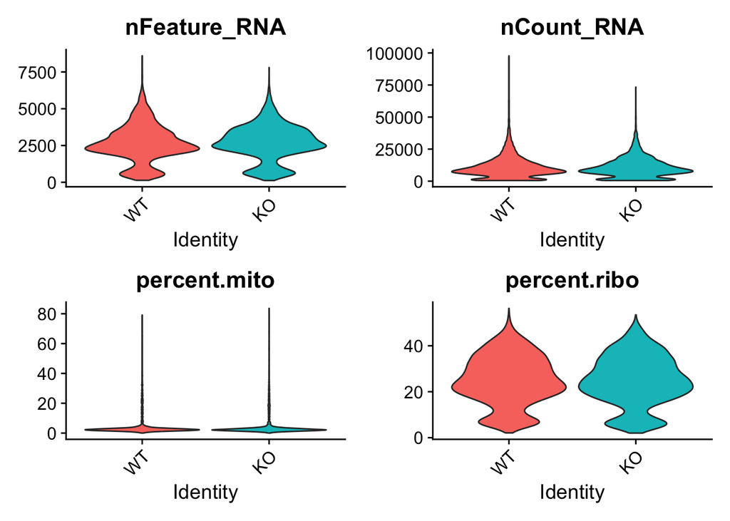

```r
# Generate before filtering quality plots
qcbefore=VlnPlot(allsamples,features = c("nFeature_RNA", "nCount_RNA","percent.mito","percent.ribo"),ncol = 2, pt.size = 0) +
  NoLegend()
qcbefore
```

```r
# Save the plot in current working directory
ggsave(paste(outputpath,"LCMV-before-qc-violineplot.pdf",sep=""), plot = qcbefore, width = 15, height = 20, units = "cm")

api_key_file = "/singlecellassistant/api_keys.txt"

# Analyze quality of the cells using SCassist
allsamplesquality <- SCassist_analyze_quality("allsamples", percent_mt = "percent.mito", percent_ribo = "percent.ribo", percent_hb = "percent.hb", api_key_file=api_key_file, llm_server="google")
```

```
## Based on the data summary, below are my recommendations for the quality filtering of the data:
##
## **nCount_RNA:**
##
## * **Lower Cutoff:**  1500. This value is chosen to be slightly above the 5th percentile (947) to remove cells with very low counts, but still capture a significant portion of the data.
## * **Upper Cutoff:** 35000. This value is chosen to be slightly below the 95th percentile (26528) to remove cells with extremely high counts, which could indicate potential doublets or other artifacts.
##
## **nFeature_RNA:**
##
## * **Lower Cutoff:** 700. This value is chosen to be slightly above the 5th percentile (528) to remove cells with very few detected genes, but still capture a significant portion of the data.
## * **Upper Cutoff:** 5500. This value is chosen to be slightly below the 95th percentile (4793) to remove cells with an unusually high number of detected genes, which could indicate potential doublets or other artifacts.
##
## **percent.mito:**
##
## * **Upper Cutoff:** 15. This value is chosen to be significantly lower than the 95th percentile (23.01) to remove cells with a high percentage of mitochondrial reads, which could indicate cell stress or damage.
##
## **percent.ribo:**
##
## * **Upper Cutoff:** 45. This value is chosen to be slightly lower than the 95th percentile (41.97) to remove cells with a high percentage of ribosomal reads, which could indicate cell stress or damage.
##
## **percent.hb:**
##
## * **Upper Cutoff:** 0.025. This value is chosen to be slightly higher than the 95th percentile (0.019) to remove cells with a high percentage of hemoglobin reads, which could indicate contamination from blood cells.
##
## **Important Note:** These are just recommendations, and the researcher should test a range of values around these recommendations to determine the optimal cutoffs for their specific dataset. The optimal cutoffs will depend on the specific characteristics of the data and the research question bein…
```

```r
# Filter data based on the above plot.
allsamplesgood <- subset(allsamples, subset =  nCount_RNA > 1500 & nCount_RNA < 35000 & nFeature_RNA > 700 & nFeature_RNA < 5500 & percent.mito < 15 & percent.ribo < 45 & percent.hb < 0.025)

# Counts before filtering
table(allsamples$orig.ident)
```

```
##
##   KO   WT
## 4885 5666
```

```r
# Counts after filtering
table(allsamplesgood$orig.ident)
```

```
##
##   KO   WT
## 3979 4576
```